# Coding the basic dungeon generator

To create the dungeon we first need to figure out what are the parameters for driving the procedural content.

For this simple algorithm we’ll use:

- level/map size in tiles because we’ll be using the *TileMap* node
- minimum and maximum room sizes for both vertical and horizontal directions
- the maximum number of possible rooms

Since we’ll create rectangular rooms it sounds like a good use of the `Rect2` class. Let’s go over the algorithm conceptually:

Given that we skip rooms if they intersect with previously placed rooms, we don’t have to generate a random number of rooms to iterate over. Randomly placing them will ensure that the total number of rooms is also random.

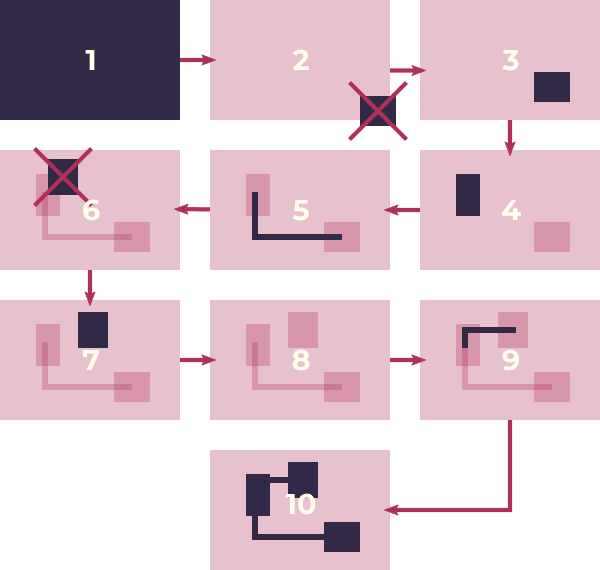

## Preparing the scene

First, create a new Godot project if you haven’t done so. From our [Procedural Generation](https://github.com/GDQuest/godot-procedural-generation) demos project copy the `Common` folder over to your local project. It contains a tile set resource that we’ll be using through this project. **Remember we have to preserve the file structure so copy the entire directory, not olny the files inside of it**.

Before moving on you might want to change the default background color to something lighter because our tile set has a dark purple color. You can do so by going to *Project > Project Settings… > Rendering > Environment* and changing the *Default Clear Color* option. We’re using the bright cream color from the [Pear36](https://lospec.com/palette-list/pear36) palette: `#ffffeb`.

Now let’s prepare the scene file. Choose *2D Scene* from the *Scene* docker. Save it as `BasicDungeon.tscn`.

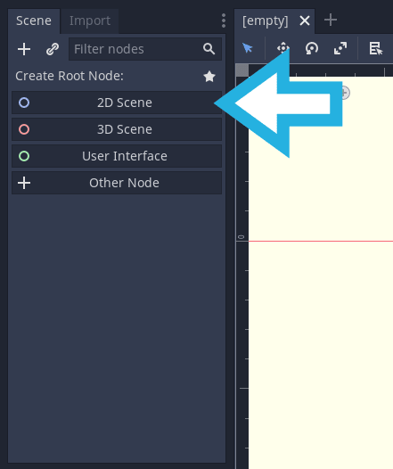

Rename the root node to *BasicDungeon* node and add the following new nodes:

- *TileMap*: rename to *Level* and follow the instructions in the image below to assign `tileset-prototype.tres` to the *Tile Set* property in the *Inspector*. Also note that we changed *Size* to `Vector2(60, 60)`.
- *Camera2D*: turn on *Current* in the *Inspector* docker as it isn’t by default.

That’s all we need to get this rolling. You should have the following now:

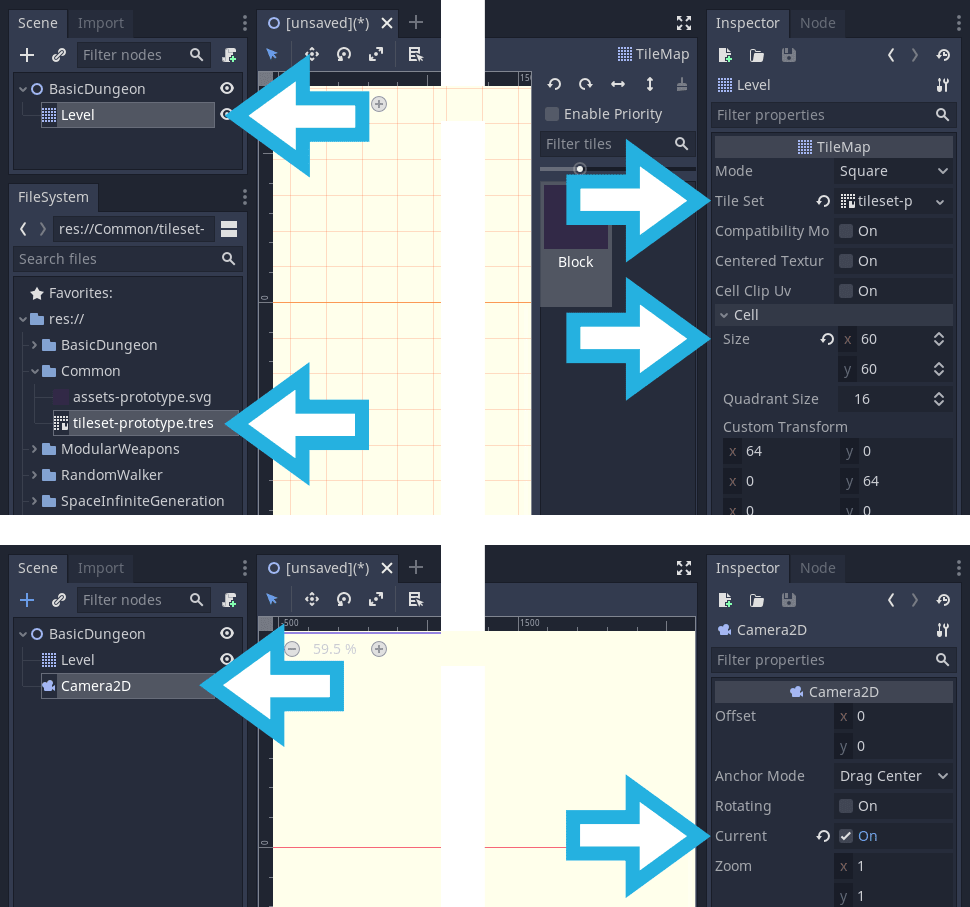

## The script

Attach a new script to the *BasicDungeon* node and define the following variables:

```
extends Node2D


export var level_size := Vector2(100, 80)
export var rooms_size := Vector2(10, 14)
export var rooms_max := 15

onready var level: TileMap = $Level
onready var camera: Camera2D = $Camera2D
```

We create `level_size`, `rooms_size` and `rooms_max` as `export` variables so that we can get easy access to them in the *Inspector*.

We’ll use `rooms_size` a bit differently. It’s not the `X` and `Y` size of a room, but instead we’ll use `rooms_size.x` to mean the minimum value of tiles a room can take on either of the axes. And we use `rooms_size.y` to mean the maximum instead. We’re using a 2D vector to store information about an interval, `[rooms_size.x, rooms_size.y]` in this case.

Create the `_ready()` function with the following content:

```
func _ready() -> void:
    _setup_camera()
    _generate()
```

We use `_setup_camera()` to position the camera in the middle of the level, based on `level_size`. We also calculate a suitable `zoom` factor:

```
func _setup_camera() -> void:
    camera.position = level.map_to_world(level_size / 2)
    var z := max(level_size.x, level_size.y) / 8
    camera.zoom = Vector2(z, z)
```

We place the camera at a position using `TileMap.map_to_world()` which converts a 2D vector from tile map coordinates to pixel coordinates.

We then calculate the camera `zoom` factor by dividing the maximum between `level_size.x` and `level_size.y` with an arbitrary value that seems to work in this case. Note that `Camera2D.zoom > 1` zooms out by that factor since Godot enlarges the camera boundaries by the zoom factor. See the picture below for a visual representation.

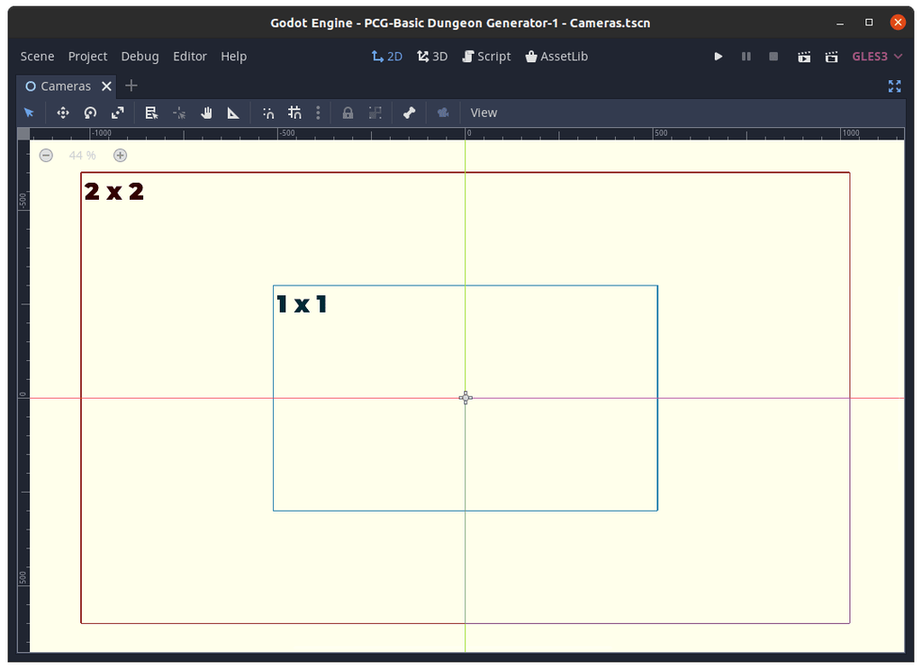

### Implementing the algorithm

We can now talk about the algorithm. The first step in deciding what to do is to pick a data structure to hold our information.

Since this is a simple dungeon generator which places rooms and corridors using a *TileMap* node, we can store `Vector2` points into a dictionary as keys representing the location in *TileMap* coordinates where we’d like to dig. The values aren’t important so we’ll just use `null`.

We use a dictionary as opposed to an array because operations like inserting elements is much faster and it also prevents adding the same element multiple times.

We’ll go over the algorithm, step by step, starting with the top-level functions and moving to the implementations of the low-level building blocks.

We first clear the *TileMap* `level` data with `TileMap.clear()`. Next we go over the 2D vector data points in a loop, and for each, we set the given cell to use the tile with index `0`, which is the only available tile type at our disposal for this project.

```
func _generate() -> void:
    level.clear()
    for vector in _generate_data():
        level.set_cellv(vector, 0)
```

`_generate_data()` is the bulk of the algorithm. This is where we generate the data we’re going to use in the *Level* node.

```
func _generate_data() -> Array:
    var rng := RandomNumberGenerator.new()
    rng.randomize()

    var data := {}
    var rooms := []
    for r in range(rooms_max):
        var room := _get_random_room(rng)
        if _intersects(rooms, room):
            continue

        _add_room(data, rooms, room)
        if rooms.size() > 1:
            var room_previous: Rect2 = rooms[-2]
            _add_connection(rng, data, room_previous, room)
    return data.keys()
```

We divide this function into smaller manageable chunks with descriptive names. This way we understand what the function does without going over the low-level implementation details. This is always a good approach to coding as it allows us keep track of our code even after a long pause.

We first define and initialize necessary variables for our algorithm:

```
var rng := RandomNumberGenerator.new()
rng.randomize()

var data := {}
var rooms := []
```

To produce randomly placed rooms we need a random number generator, which we’ll store in the `rng` variable. We need to use `RandomNumberGenerator.randomize()` method so that Godot produces different sequences of pseudo-random numbers each time we call the `_generate_data()` function. Otherwise we’d get the same output every time.

Note that generating pseudo-random numbers isn’t bad because it gives us control over the generated data so we can debug or perhaps recall a specific level. We could for example save the seed value for a specific level and re-generate it when needed instead of saving the level data directly.

We store our *TileMap* information in the `data` dictionary.

`rooms` is an array for keeping track of all the random rooms we generate. We use this data to check for intersections as this algorithm places new rooms only if they don’t intersect with previously placed rooms.

Moving on, we have the main loop body, iterating up to `rooms_max`.

```
for r in range(rooms_max):
    var room := _get_random_room(rng)
    if _intersects(rooms, room):
        continue
```

We first generate a random room with `_get_random_room()` and if we detect an intersection we skip the rest of the code using the `continue` statement. What this means is that we won’t place a room on each iteration step so we’ll end up with a random number of rooms up to `rooms_max` most times.

We complete the loop with:

```
_add_room(data, rooms, room)
if rooms.size() > 1:
    var room_previous: Rect2 = rooms[-2]
    _add_connection(rng, data, room_previous, room)
```

Here we first add the room into the `data` dictionary as well as the `rooms` arrays. They’re stored in different ways so we need both of these data structures.

We finish up the loop by checking if we have more than one room stored in the `rooms` array. If so then we add a connection between the currently generated room and the previous room. The previous room is the second to last and we get it using a negative index: `rooms[-2]`. We’re getting the second to last room because `_add_room` already adds it in the `rooms` array. This means that `rooms[-1]` (the last element in the array) and `room` are the same object at this point.

This piece of code also reveals that we’re using `Rect2` for our underlying room data type. We strive to use as much of the built-in functionality as we can get. `Rect2` is beneficial here because it gives us the `Rect2.intersects()` method which we use in `_intersects()` function to figure out if rooms overlap.

Now we’re ready to return the data. Since we’re only interested in the keys of the dictionary, we return them as an array rather than the dictionary itself:

```
return data.keys()
```

Let’s move on to the implementation of the low-level functions now.

We construct a random `Rect2` with `_get_random_room()`:

```
func _get_random_room(rng: RandomNumberGenerator) -> Rect2:
    var width := rng.randi_range(rooms_size.x, rooms_size.y)
    var height := rng.randi_range(rooms_size.x, rooms_size.y)
    var x := rng.randi_range(0, level_size.x - width - 1)
    var y := rng.randi_range(0, level_size.y - height - 1)
    return Rect2(x, y, width, height)
```

We’re using the `RandomNumberGenerator.randi_range()` function to generate a random `Rect2` in both position and size.

Note that `RandomNumberGenerator.randi_range()` is an inclusive function, that is, `rng.randi_range(0, 10)` returns a number between `0` and `10` inclusive.

In `_add_room()` we use `room` to populate both `data` and `rooms` variables. We save `Vector2` positions in `data` that comprise the room interior, based on `Rect2.position` and `Rect2.end` vectors. Inside the `rooms` array we store the `Rect2` room itself so we can later use it to test if it intersects other rooms.

```
func _add_room(data: Dictionary, rooms: Array, room: Rect2) -> void:
    rooms.push_back(room)
    for x in range(room.position.x, room.end.x):
        for y in range(room.position.y, room.end.y):
            data[Vector2(x, y)] = null
```

With `_add_connection()` we add corridors between two given rooms, starting and ending in the middle of the rooms.

```
func _add_connection(rng: RandomNumberGenerator, data: Dictionary, room1: Rect2, room2: Rect2) -> void:
    var room_center1 := (room1.position + room1.end) / 2
    var room_center2 := (room2.position + room2.end) / 2
    if rng.randi_range(0, 1) == 0:
        _add_corridor(data, room_center1.x, room_center2.x, room_center1.y, Vector2.AXIS_X)
        _add_corridor(data, room_center1.y, room_center2.y, room_center2.x, Vector2.AXIS_Y)
    else:
        _add_corridor(data, room_center1.y, room_center2.y, room_center1.x, Vector2.AXIS_Y)
        _add_corridor(data, room_center1.x, room_center2.x, room_center2.y, Vector2.AXIS_X)
```

For this we’ll use `_add_corridor()` which adds data about corridors horizontally or vertically depending on the last parameter sent to it.

First we calculate the given `room1` and `room2` center coordinates and with the help of `RandomNumberGenerator`, we’ll make corridors starting horizontally or vertically with a 50% chance.

To understand how `_add_connection()` works we’ll look at `_add_corridor()`:

```
func _add_corridor(data: Dictionary, start: int, end: int, constant: int, axis: int) -> void:
    for t in range(min(start, end), max(start, end) + 1):
        var point := Vector2.ZERO
        match axis:
            Vector2.AXIS_X: point = Vector2(t, constant)
            Vector2.AXIS_Y: point = Vector2(constant, t)
        data[point] = null
```

This function takes in `data` as the first parameter, to add information about the corridor as needed. Then we have the corridor `start` and `end` coordinates. Depending on `axis`, we take the variable coordinate to be either on *X* or *Y* axis and `constant` will be on the opposite axis: either *Y* or *X* respectively.

We finally add these points to the `data` dictionary.

We have one last function to cover, the `_intersects()` function:

```
func _intersects(rooms: Array, room: Rect2) -> bool:
    var out := false
    for room_other in rooms:
        if room.intersects(room_other):
            out = true
            break
    return out
```

We use it inside the main loop, in the `_generate_data()` function to test if the current room we want to place intersects any other room we have already placed. This is a simple matter for us to check, since we rely on the `Rect2.intersects()` method to do it for us. All we do is iterate over the previously placed rooms and check if they intersect with the current room in which case we assign `true` to `out` and break from the loop otherwise we continue with the loop. If there are no intersections detected then `out` will remain `false`.

With this last function, we’re done and if you run the project now you’ll get results like in the following image:

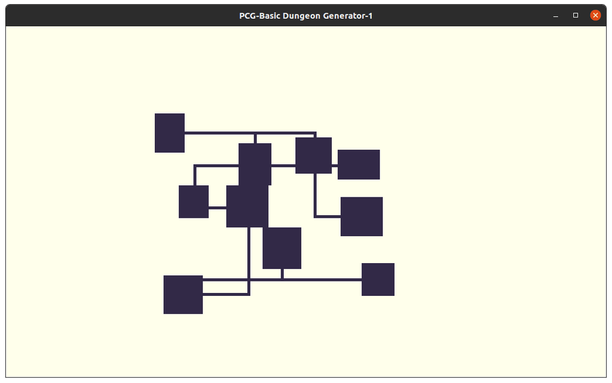

### References

For reference here is the entire code from `BasicDungeon.gd`:

```
extends Node2D


export var level_size := Vector2(100, 80)
export var rooms_size := Vector2(10, 14)
export var rooms_max := 15

onready var level: TileMap = $Level
onready var camera: Camera2D = $Camera2D


func _ready() -> void:
    _setup_camera()
    _generate()


func _setup_camera() -> void:
    camera.position = level.map_to_world(level_size / 2)
    var z := max(level_size.x, level_size.y) / 8
    camera.zoom = Vector2(z, z)


func _generate() -> void:
    level.clear()
    for vector in _generate_data():
        level.set_cellv(vector, 0)


func _generate_data() -> Array:
    var rng := RandomNumberGenerator.new()
    rng.randomize()

    var data := {}
    var rooms := []
    for r in range(rooms_max):
        var room := _get_random_room(rng)
        if _intersects(rooms, room):
            continue

        _add_room(data, rooms, room)
        if rooms.size() > 1:
            var room_previous: Rect2 = rooms[-2]
            _add_connection(rng, data, room_previous, room)
    return data.keys()


func _get_random_room(rng: RandomNumberGenerator) -> Rect2:
    var width := rng.randi_range(rooms_size.x, rooms_size.y)
    var height := rng.randi_range(rooms_size.x, rooms_size.y)
    var x := rng.randi_range(0, level_size.x - width - 1)
    var y := rng.randi_range(0, level_size.y - height - 1)
    return Rect2(x, y, width, height)


func _add_room(data: Dictionary, rooms: Array, room: Rect2) -> void:
    rooms.push_back(room)
    for x in range(room.position.x, room.end.x):
        for y in range(room.position.y, room.end.y):
            data[Vector2(x, y)] = null


func _add_connection(rng: RandomNumberGenerator, data: Dictionary, room1: Rect2, room2: Rect2) -> void:
    var room_center1 := (room1.position + room1.end) / 2
    var room_center2 := (room2.position + room2.end) / 2
    if rng.randi_range(0, 1) == 0:
        _add_corridor(data, room_center1.x, room_center2.x, room_center1.y, Vector2.AXIS_X)
        _add_corridor(data, room_center1.y, room_center2.y, room_center2.x, Vector2.AXIS_Y)
    else:
        _add_corridor(data, room_center1.y, room_center2.y, room_center1.x, Vector2.AXIS_Y)
        _add_corridor(data, room_center1.x, room_center2.x, room_center2.y, Vector2.AXIS_X)


func _add_corridor(data: Dictionary, start: int, end: int, constant: int, axis: int) -> void:
    for t in range(min(start, end), max(start, end) + 1):
        var point := Vector2.ZERO
        match axis:
            Vector2.AXIS_X: point = Vector2(t, constant)
            Vector2.AXIS_Y: point = Vector2(constant, t)
        data[point] = null


func _intersects(rooms: Array, room: Rect2) -> bool:
    var out := false
    for room_other in rooms:
        if room.intersects(room_other):
            out = true
            break
    return out
```